# act_report

```python
import pandas as pd
import matplotlib.pyplot as plt
import seaborn as sns
```

```python
tweet_merge = pd.read_csv('pl1_tweet_merge.csv')
top_favorite = pd.read_csv('pl3_top_favorite.csv')
top10_fav = pd.read_csv('top10_fav.csv')
```

### Data Wrangling - We Rate Dogs (Twitter)

#### Introduction

The dataset for this project is the twitter archieve of a twitter user @dog_rates also known as WeRateDogs. The twitter user rates people dog with humorous comments and has gained massive popularity and recognition online. The data was gathered from three sources; the twitter-archive-enhanced.csv, image_prediction.tsv and tweet-json.txt as described in the wrangle_report.The dataset contains 2356 tweets of the 5000 between November 2015 and August 2017.

#### Data Wrangling

Data wrangling activities were conducted including gathering the data (Both manual and programatic downloading of data file from Udacity sever), accessing the data(Both visually and programmatically) and cleaning the data. The wrangle_report file is a separate report containing details of these steps.

### Most dog were rated between 10 - 12.

```
[Text(0.5, 1.0, 'Plot showing Rating distribution')]
```

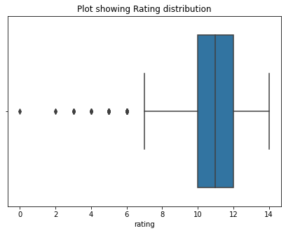

```python
plt.figure(figsize= (7,5))
sns.boxplot(data= tweet_merge, x = 'rating').set(title = 'Plot showing Rating distribution')
```

### iPhone is the major source of the pictures

```
[Text(0.5, 1.0, 'Frequency plot of Source')]
```

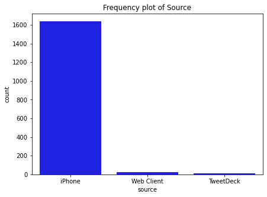

```python
plt.figure(figsize= (7,5))
sns.countplot(data= tweet_merge, x= 'source', color = 'b').set(title = 'Frequency plot of Source')
```

Over 1600 of the the dog picture posted were from iPhone making up for over 95% of the total. This means a very small percentage of picture came from the other sources which are web client and tweetdeck

### Favorite count has a strong positive linear relationship with retweet count

```
[Text(0.5, 1.0, 'Retweet count vs Favorite count')]
```

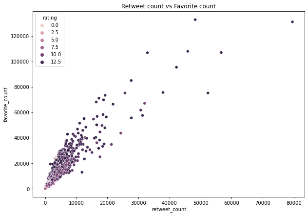

```python
plt.figure(figsize = (10, 7))
sns.scatterplot(data= tweet_merge , x = 'retweet_count', y = 'favorite_count', hue = 'rating').set(title = 'Retweet count vs Favorite count')
```

### So many Retrievers

```
[Text(0.5, 1.0, 'Top predicted dog breeds')]
```

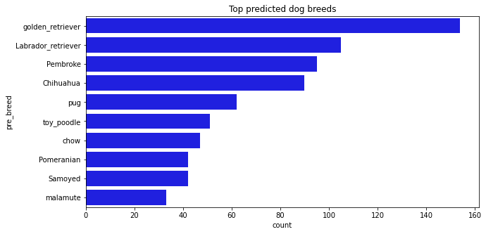

```python
plt.figure(figsize = (10, 5))
sns.countplot(data= tweet_merge, y = 'pre_breed', order = tweet_merge.pre_breed.value_counts().iloc[:10].index, color = 'b').set(title = 'Top predicted dog breeds')
```

```
[Text(0.5, 1.0, 'Rating Distribution of Top 10 predicted')]
```

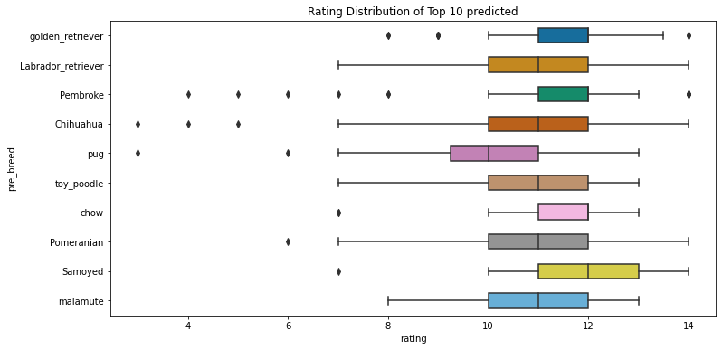

```python
plt.figure(figsize = (12, 6))
sns.boxplot(y = 'pre_breed', x = 'rating',
                    data = tweet_merge,
                    orient = 'h',
                    width = 0.5,
                    palette = "colorblind",
                    order = tweet_merge.pre_breed.value_counts().iloc[:10].index).set(title = 'Rating Distribution of Top 10 predicted')
```

The top 10 dog breeds predicted by the neural network shows more of golden retrievers and labrador retrievers. The top 10 breeds had a rating distribution similar to the entire data with more rating around 10 to 12

### People loved the Saluki breed

```python
top10_fav.head()
```

|  | pre_breed | rating | img_num | pre_conf | retweet_count | favorite_count |
| --- | --- | --- | --- | --- | --- | --- |
| 0 | Saluki | 12.500000 | 1.00000 | 0.523054 | 5133.750000 | 24060.000000 |
| 1 | Bedlington_terrier | 10.333333 | 1.00000 | 0.286043 | 7510.166667 | 21153.166667 |
| 2 | French_bulldog | 11.193548 | 1.16129 | 0.662573 | 5039.677419 | 18416.806452 |
| 3 | Bouvier_des_Flandres | 13.000000 | 1.00000 | 0.082610 | 4479.000000 | 18032.000000 |
| 4 | Afghan_hound | 9.666667 | 1.00000 | 0.433959 | 5976.000000 | 17326.666667 |

```
[Text(0.5, 1.0, 'Top 10 average favorite count against dog breed')]
```

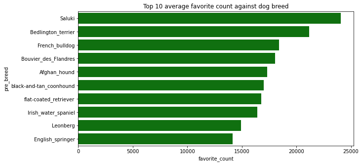

```python
plt.figure(figsize = (10, 5))
sns.barplot(data=top10_fav, x = 'favorite_count', y= 'pre_breed', color= 'g').set(title = 'Top 10 average favorite count against dog breed')
```

The plot show the breeds with the highest means favorite count. The Saluki breed comes top which means not much of it may have been posted as it was not in the top 10 predicted breeds but had lot of like and consequently lots of retweet as well.